# Super Kart Sales Prediction

## **Data Preprocessing**

### **Feature Engineering**

**Calculating Store Age to be stored in the data set and incorporated into the model**

```python
data['Store_Age_Years'] = 2024 - data['Store_Establishment_Year']
```

```python
data.head()
```

|  | Product_Weight | Product_Sugar_Content | Product_Allocated_Area | Product_Type | Product_MRP | Store_Id | Store_Establishment_Year | Store_Size | Store_Location_City_Type | Store_Type | Product_Store_Sales_Total | Product_Id_char | Store_Age_Years |
| --- | --- | --- | --- | --- | --- | --- | --- | --- | --- | --- | --- | --- | --- |
| 0 | 12.66 | Low Sugar | 0.027 | Frozen Foods | 117.08 | OUT004 | 2009 | Medium | Tier 2 | Supermarket Type2 | 2842.40 | FD | 15 |
| 1 | 16.54 | Low Sugar | 0.144 | Dairy | 171.43 | OUT003 | 1999 | Medium | Tier 1 | Departmental Store | 4830.02 | FD | 25 |
| 2 | 14.28 | Regular | 0.031 | Canned | 162.08 | OUT001 | 1987 | High | Tier 2 | Supermarket Type1 | 4130.16 | FD | 37 |
| 3 | 12.10 | Low Sugar | 0.112 | Baking Goods | 186.31 | OUT001 | 1987 | High | Tier 2 | Supermarket Type1 | 4132.18 | FD | 37 |
| 4 | 9.57 | No Sugar | 0.010 | Health and Hygiene | 123.67 | OUT002 | 1998 | Small | Tier 3 | Food Mart | 2279.36 | NC | 26 |

**There are 16 different product types in the dataset. We will create two broad categories (perishable and non-perishable) to reduce the number of product types.**

```python
perishables = [
    'Dairy',
    'Meat',
    'Fruits and Vegetables',
    'Breakfast',
    'Breads',
    'Seafood',
]
```

```python
def change(x):
  if x in perishables:
    return 'Perishables'
  else:
    return 'Non-Perishables'

data.Product_Type.apply(change)
```

```
0       Non-Perishables
1           Perishables
2       Non-Perishables
3       Non-Perishables
4       Non-Perishables
             ...
8758    Non-Perishables
8759    Non-Perishables
8760    Non-Perishables
8761    Non-Perishables
8762    Non-Perishables
Name: Product_Type, Length: 8763, dtype: object
```

```python
data['Product_Category'] = ''
```

```python
for i in range(0, len(data)):
  if data.Product_Type[i] in perishables:
    data.Product_Category[i] = 'Perishable'
  else:
    data.Product_Category[i] = 'Non-Perishable'
```

```python
data.head()
```

|  | Product_Weight | Product_Sugar_Content | Product_Allocated_Area | Product_Type | Product_MRP | Store_Id | Store_Establishment_Year | Store_Size | Store_Location_City_Type | Store_Type | Product_Store_Sales_Total | Product_Id_char | Store_Age_Years | Product_Category |
| --- | --- | --- | --- | --- | --- | --- | --- | --- | --- | --- | --- | --- | --- | --- |
| 0 | 12.66 | Low Sugar | 0.027 | Frozen Foods | 117.08 | OUT004 | 2009 | Medium | Tier 2 | Supermarket Type2 | 2842.40 | FD | 15 | Non-Perishable |
| 1 | 16.54 | Low Sugar | 0.144 | Dairy | 171.43 | OUT003 | 1999 | Medium | Tier 1 | Departmental Store | 4830.02 | FD | 25 | Perishable |
| 2 | 14.28 | Regular | 0.031 | Canned | 162.08 | OUT001 | 1987 | High | Tier 2 | Supermarket Type1 | 4130.16 | FD | 37 | Non-Perishable |
| 3 | 12.10 | Low Sugar | 0.112 | Baking Goods | 186.31 | OUT001 | 1987 | High | Tier 2 | Supermarket Type1 | 4132.18 | FD | 37 | Non-Perishable |
| 4 | 9.57 | No Sugar | 0.010 | Health and Hygiene | 123.67 | OUT002 | 1998 | Small | Tier 3 | Food Mart | 2279.36 | NC | 26 | Non-Perishable |

## **Outlier Check**

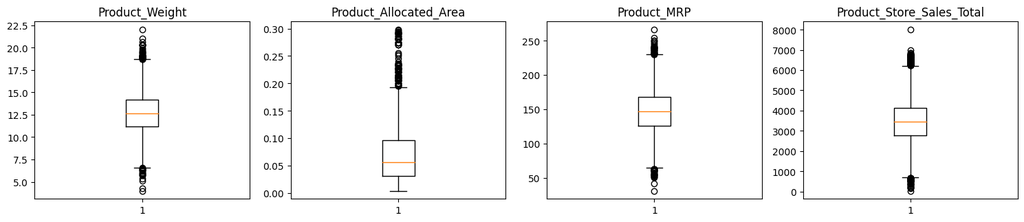

```python
# Outlier detection using boxplot
num_cols = data.select_dtypes(include = np.number).columns.tolist()
num_cols.remove('Store_Establishment_Year')
num_cols.remove('Store_Age_Years')

plt.figure(figsize = (15, 12))

for i, variable in enumerate(num_cols):
  plt.subplot(4, 4, i + 1)
  plt.boxplot(data[variable], whis = 1.5)
  plt.tight_layout()
  plt.title(variable);
```

**Observations:**

- There are a lot of outliers in the dataset, however we will leave them in the dataset as there are no indications that they are not proper values.

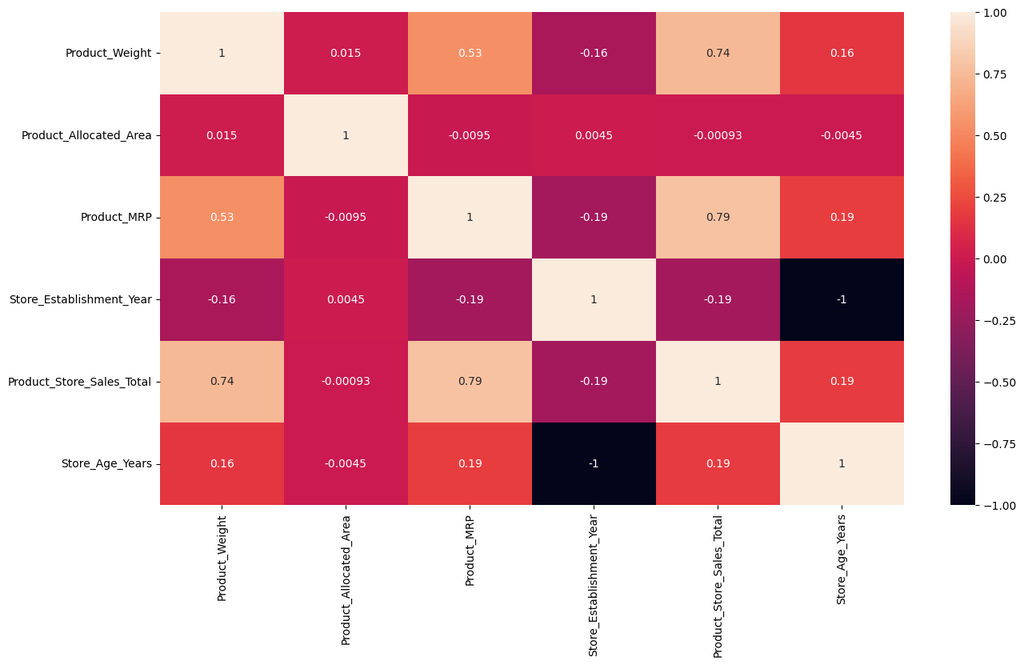

```python
plt.figure(figsize = (15, 8))
sns.heatmap(data.corr(numeric_only = True), annot = True);
```

**Observations:**

- We can see a high correlation between Product_Store_Sales_Total and Product_MRP, as well as between Product_Store_Sales_Total and Product_Weight.

## **Data Preparation for Modeling**

- We want to forecast Product_Store_Sales_Total.
- Before we proceed, we need to encode categorical features and drop unnecessary columns.
- We'll split the data in to train and test setst to evaluate the model we build.

```python
# Copying the dataset into a model dataset and dropping useless columns
df_model = data.drop(['Product_Type', 'Store_Id', 'Store_Establishment_Year'], axis = 1)
```

```python
# Creating dummy columns for categorical variables
df_model = pd.get_dummies(
    df_model,
    columns = df_model.select_dtypes(include = ['object', 'category']).columns.tolist(),
    drop_first = True, dtype = 'int64'
)
```

```python
# Separating features and the target column
X = df_model.drop(['Product_Store_Sales_Total'], axis  = 1)
Y = df_model['Product_Store_Sales_Total']
```

```python
X = sm.add_constant(X)
```

```python
# Splitting the data into trian/test sets 70:30 ratio
x_train, x_test, y_train, y_test = train_test_split(
    X, Y, test_size = .30, random_state = 1
)
```

```python
x_train.info()
```

```
<class 'pandas.core.frame.DataFrame'>
Index: 6134 entries, 910 to 235
Data columns (total 17 columns):
 #   Column                           Non-Null Count  Dtype
---  ------                           --------------  -----
 0   const                            6134 non-null   float64
 1   Product_Weight                   6134 non-null   float64
 2   Product_Allocated_Area           6134 non-null   float64
 3   Product_MRP                      6134 non-null   float64
 4   Store_Age_Years                  6134 non-null   int64
 5   Product_Sugar_Content_No Sugar   6134 non-null   int64
 6   Product_Sugar_Content_Regular    6134 non-null   int64
 7   Store_Size_Medium                6134 non-null   int64
 8   Store_Size_Small                 6134 non-null   int64
 9   Store_Location_City_Type_Tier 2  6134 non-null   int64
 10  Store_Location_City_Type_Tier 3  6134 non-null   int64
 11  Store_Type_Food Mart             6134 non-null   int64
 12  Store_Type_Supermarket Type1     6134 non-null   int64
 13  Store_Type_Supermarket Type2     6134 non-null   int64
 14  Product_Id_char_FD               6134 non-null   int64
 15  Product_Id_char_NC               6134 non-null   int64
 16  Product_Category_Perishable      6134 non-null   int64
dtypes: float64(4), int64(13)
memory usage: 862.6 KB
```

```python
x_train.head()
```

|  | const | Product_Weight | Product_Allocated_Area | Product_MRP | Store_Age_Years | Product_Sugar_Content_No Sugar | Product_Sugar_Content_Regular | Store_Size_Medium | Store_Size_Small | Store_Location_City_Type_Tier 2 | Store_Location_City_Type_Tier 3 | Store_Type_Food Mart | Store_Type_Supermarket Type1 | Store_Type_Supermarket Type2 | Product_Id_char_FD | Product_Id_char_NC | Product_Category_Perishable |
| --- | --- | --- | --- | --- | --- | --- | --- | --- | --- | --- | --- | --- | --- | --- | --- | --- | --- |
| 910 | 1.0 | 11.73 | 0.071 | 132.08 | 15 | 0 | 1 | 1 | 0 | 1 | 0 | 0 | 0 | 1 | 1 | 0 | 0 |
| 7022 | 1.0 | 11.61 | 0.062 | 150.70 | 15 | 0 | 1 | 1 | 0 | 1 | 0 | 0 | 0 | 1 | 0 | 0 | 0 |
| 8056 | 1.0 | 11.30 | 0.039 | 102.35 | 26 | 0 | 0 | 0 | 1 | 0 | 1 | 1 | 0 | 0 | 1 | 0 | 1 |
| 2939 | 1.0 | 12.55 | 0.095 | 139.35 | 15 | 0 | 0 | 1 | 0 | 1 | 0 | 0 | 0 | 1 | 1 | 0 | 1 |
| 68 | 1.0 | 12.95 | 0.076 | 155.55 | 15 | 0 | 1 | 1 | 0 | 1 | 0 | 0 | 0 | 1 | 1 | 0 | 1 |

## **Checking for Multicollinearity**

```python
from statsmodels.stats.outliers_influence import variance_inflation_factor

# function to check VIF
def check_vif(train):
    vif = pd.DataFrame()
    vif['feature'] = train.columns

    # checking VIF for each feature
    vif['VIF'] = [
        variance_inflation_factor(train.values, i) for i in range(len(train.columns))
    ]
    return vif

print(check_vif(x_train))
```

```
                            feature       VIF
0                             const  0.000000
1                    Product_Weight  1.752928
2            Product_Allocated_Area  1.001184
3                       Product_MRP  1.885058
4                   Store_Age_Years       inf
5    Product_Sugar_Content_No Sugar       inf
6     Product_Sugar_Content_Regular  1.088506
7                 Store_Size_Medium       inf
8                  Store_Size_Small       inf
9   Store_Location_City_Type_Tier 2       inf
10  Store_Location_City_Type_Tier 3       inf
11             Store_Type_Food Mart       inf
12     Store_Type_Supermarket Type1       inf
13     Store_Type_Supermarket Type2       inf
14               Product_Id_char_FD  2.774371
15               Product_Id_char_NC       inf
16      Product_Category_Perishable  1.217690
```

**Observation:**

```python
# dropping Store_Age_Years from both train and test sets
x_train = x_train.drop(['Store_Age_Years'], axis = 1)
x_test = x_test.drop(['Store_Age_Years'], axis = 1)
```

```python
# rechecking VIF after dropping Store_Age_Years
from statsmodels.stats.outliers_influence import variance_inflation_factor

# function to check VIF
def check_vif(train):
    vif = pd.DataFrame()
    vif['feature'] = train.columns

    # checking VIF for each feature
    vif['VIF'] = [
        variance_inflation_factor(train.values, i) for i in range(len(train.columns))
    ]
    return vif

print(check_vif(x_train))
```

```
                            feature       VIF
0                             const  0.000000
1                    Product_Weight  1.752928
2            Product_Allocated_Area  1.001184
3                       Product_MRP  1.885058
4    Product_Sugar_Content_No Sugar       inf
5     Product_Sugar_Content_Regular  1.088506
6                 Store_Size_Medium       inf
7                  Store_Size_Small       inf
8   Store_Location_City_Type_Tier 2       inf
9   Store_Location_City_Type_Tier 3       inf
10             Store_Type_Food Mart       inf
11     Store_Type_Supermarket Type1       inf
12     Store_Type_Supermarket Type2       inf
13               Product_Id_char_FD  2.774371
14               Product_Id_char_NC       inf
15      Product_Category_Perishable  1.217690
```

## **Building Models**

```python
# Creating a function to test the model performance

from sklearn.metrics import r2_score, mean_absolute_percentage_error, mean_absolute_error, mean_squared_error

# Model performance on test and train data
def model_perf(olsmodel, x_train, x_test):

  # In-sample prediction
  y_pred_train = olsmodel.predict(x_train)
  y_observed_train = y_train

  # Prediciton on test data
  y_pred_test = olsmodel.predict(x_test)
  y_observed_test = y_test

  print(
      pd.DataFrame(
          {
              'Data': ['Train', 'Test'],
              'RMSE': [
                  np.sqrt(mean_squared_error(y_pred_train, y_observed_train)),
                  np.sqrt(mean_squared_error(y_pred_test, y_observed_test)),
              ],
              'MAE': [
                  mean_absolute_error(y_pred_train, y_observed_train),
                  mean_absolute_error(y_pred_test, y_observed_test),
              ],
              'r2': [
                  r2_score(y_pred_train, y_observed_train),
                  r2_score(y_pred_test, y_observed_test),
              ]
          }
      )
  )
```

```python
# creating the model
model1 = sm.OLS(y_train, x_train).fit()

# get model summary
model1.summary()
```

OLS Regression Results

| Dep. Variable: | Product_Store_Sales_Total | R-squared: | 0.824 |
| --- | --- | --- | --- |
| Model: | OLS | Adj. R-squared: | 0.823 |
| Method: | Least Squares | F-statistic: | 2860. |
| Date: | Thu, 06 Jun 2024 | Prob (F-statistic): | 0.00 |
| Time: | 18:24:18 | Log-Likelihood: | -46132. |
| No. Observations: | 6134 | AIC: | 9.229e+04 |
| Df Residuals: | 6123 | BIC: | 9.236e+04 |
| Df Model: | 10 |  |  |
| Covariance Type: | nonrobust |  |  |

|  | coef | std err | t | P>\|t\| | [0.025 | 0.975] |
| --- | --- | --- | --- | --- | --- | --- |
| const | 176.6077 | 42.659 | 4.140 | 0.000 | 92.982 | 260.234 |
| Product_Weight | 135.0943 | 3.436 | 39.318 | 0.000 | 128.359 | 141.830 |
| Product_Allocated_Area | -139.5679 | 118.876 | -1.174 | 0.240 | -372.608 | 93.472 |
| Product_MRP | 12.8696 | 0.254 | 50.702 | 0.000 | 12.372 | 13.367 |
| Product_Sugar_Content_No Sugar | 16.0039 | 12.324 | 1.299 | 0.194 | -8.155 | 40.163 |
| Product_Sugar_Content_Regular | 30.8608 | 13.284 | 2.323 | 0.020 | 4.819 | 56.902 |
| Store_Size_Medium | 394.3947 | 26.547 | 14.856 | 0.000 | 342.353 | 446.436 |
| Store_Size_Small | -383.1731 | 5.776 | -66.339 | 0.000 | -394.496 | -371.850 |
| Store_Location_City_Type_Tier 2 | -308.1516 | 8.855 | -34.801 | 0.000 | -325.510 | -290.794 |
| Store_Location_City_Type_Tier 3 | -383.1731 | 5.776 | -66.339 | 0.000 | -394.496 | -371.850 |
| Store_Type_Food Mart | -383.1731 | 5.776 | -66.339 | 0.000 | -394.496 | -371.850 |
| Store_Type_Supermarket Type1 | 165.3861 | 17.762 | 9.311 | 0.000 | 130.566 | 200.206 |
| Store_Type_Supermarket Type2 | -473.5378 | 17.176 | -27.570 | 0.000 | -507.208 | -439.867 |
| Product_Id_char_FD | 0.3932 | 21.936 | 0.018 | 0.986 | -42.609 | 43.396 |
| Product_Id_char_NC | 16.0039 | 12.324 | 1.299 | 0.194 | -8.155 | 40.163 |
| Product_Category_Perishable | 7.7111 | 13.233 | 0.583 | 0.560 | -18.231 | 33.653 |

| Omnibus: | 1745.262 | Durbin-Watson: | 1.987 |
| --- | --- | --- | --- |
| Prob(Omnibus): | 0.000 | Jarque-Bera (JB): | 46497.082 |
| Skew: | 0.775 | Prob(JB): | 0.00 |
| Kurtosis: | 16.399 | Cond. No. | 6.25e+18 |

Notes:  
[1] Standard Errors assume that the covariance matrix of the errors is correctly specified.  
[2] The smallest eigenvalue is 3.57e-30. This might indicate that there are  
strong multicollinearity problems or that the design matrix is singular.

```python
# checking model1 performance
model_perf(model1, x_train, x_test)
```

```
    Data        RMSE         MAE        r2
0  Train  446.667654  262.110666  0.785927
1   Test  446.685287  266.690587  0.790208
```

**Observations:**

- The train and test scores are very close together, which means there are no signs of overfitting.
- The test scores are slightly better than the training scores, so there may be room to improve the performance of the model.
- A few of our variables have very high p-values so we will start by eliminating those variables from the model first.

```python
# dropping insignificant variables from train and test sets
x_train2 = x_train.drop(['Product_Category_Perishable', 'Product_Id_char_FD'], axis = 1)

x_test2 = x_test.drop(['Product_Category_Perishable', 'Product_Id_char_FD'], axis = 1)
```

## **Creating the 2nd Model w/ removed variables**

```python
# Creating the model
model2 = sm.OLS(y_train, x_train2).fit()

# Getting model summary
model2.summary()
```

OLS Regression Results

| Dep. Variable: | Product_Store_Sales_Total | R-squared: | 0.824 |
| --- | --- | --- | --- |
| Model: | OLS | Adj. R-squared: | 0.823 |
| Method: | Least Squares | F-statistic: | 3576. |
| Date: | Thu, 06 Jun 2024 | Prob (F-statistic): | 0.00 |
| Time: | 19:08:45 | Log-Likelihood: | -46132. |
| No. Observations: | 6134 | AIC: | 9.228e+04 |
| Df Residuals: | 6125 | BIC: | 9.234e+04 |
| Df Model: | 8 |  |  |
| Covariance Type: | nonrobust |  |  |

|  | coef | std err | t | P>\|t\| | [0.025 | 0.975] |
| --- | --- | --- | --- | --- | --- | --- |
| const | 179.0666 | 40.949 | 4.373 | 0.000 | 98.793 | 259.340 |
| Product_Weight | 135.0918 | 3.435 | 39.323 | 0.000 | 128.357 | 141.827 |
| Product_Allocated_Area | -140.3752 | 118.852 | -1.181 | 0.238 | -373.367 | 92.616 |
| Product_MRP | 12.8703 | 0.254 | 50.727 | 0.000 | 12.373 | 13.368 |
| Product_Sugar_Content_No Sugar | 14.1944 | 7.933 | 1.789 | 0.074 | -1.358 | 29.747 |
| Product_Sugar_Content_Regular | 30.7219 | 13.272 | 2.315 | 0.021 | 4.704 | 56.740 |
| Store_Size_Medium | 395.6741 | 25.835 | 15.316 | 0.000 | 345.029 | 446.319 |
| Store_Size_Small | -382.7595 | 5.395 | -70.953 | 0.000 | -393.335 | -372.184 |
| Store_Location_City_Type_Tier 2 | -307.8490 | 8.636 | -35.648 | 0.000 | -324.778 | -290.920 |
| Store_Location_City_Type_Tier 3 | -382.7595 | 5.395 | -70.953 | 0.000 | -393.335 | -372.184 |
| Store_Type_Food Mart | -382.7595 | 5.395 | -70.953 | 0.000 | -393.335 | -372.184 |
| Store_Type_Supermarket Type1 | 166.1521 | 17.353 | 9.575 | 0.000 | 132.135 | 200.169 |
| Store_Type_Supermarket Type2 | -474.0011 | 17.074 | -27.762 | 0.000 | -507.472 | -440.530 |
| Product_Id_char_NC | 14.1944 | 7.933 | 1.789 | 0.074 | -1.358 | 29.747 |

| Omnibus: | 1744.629 | Durbin-Watson: | 1.987 |
| --- | --- | --- | --- |
| Prob(Omnibus): | 0.000 | Jarque-Bera (JB): | 46526.548 |
| Skew: | 0.775 | Prob(JB): | 0.00 |
| Kurtosis: | 16.403 | Cond. No. | 2.02e+19 |

Notes:  
[1] Standard Errors assume that the covariance matrix of the errors is correctly specified.  
[2] The smallest eigenvalue is 3.4e-31. This might indicate that there are  
strong multicollinearity problems or that the design matrix is singular.

```python
# Checking model2 performance
model_perf(model2, x_train2, x_test2)
```

```
    Data        RMSE         MAE        r2
0  Train  446.681336  262.125308  0.785911
1   Test  446.780252  266.790089  0.790113
```

**Observations:**

```python
# dropping insignificant variables from train and test sets
x_train3 = x_train2.drop(['Product_Allocated_Area', 'Product_Id_char_NC'], axis = 1)

x_test3 = x_test2.drop(['Product_Allocated_Area', 'Product_Id_char_NC'], axis = 1)
```

```python
# Creating the model
model3 = sm.OLS(y_train, x_train3).fit()

# Getting model summary
model3.summary()
```

OLS Regression Results

| Dep. Variable: | Product_Store_Sales_Total | R-squared: | 0.824 |
| --- | --- | --- | --- |
| Model: | OLS | Adj. R-squared: | 0.823 |
| Method: | Least Squares | F-statistic: | 4087. |
| Date: | Thu, 06 Jun 2024 | Prob (F-statistic): | 0.00 |
| Time: | 19:15:23 | Log-Likelihood: | -46133. |
| No. Observations: | 6134 | AIC: | 9.228e+04 |
| Df Residuals: | 6126 | BIC: | 9.234e+04 |
| Df Model: | 7 |  |  |
| Covariance Type: | nonrobust |  |  |

|  | coef | std err | t | P>\|t\| | [0.025 | 0.975] |
| --- | --- | --- | --- | --- | --- | --- |
| const | 172.8520 | 40.610 | 4.256 | 0.000 | 93.241 | 252.463 |
| Product_Weight | 135.0263 | 3.435 | 39.307 | 0.000 | 128.292 | 141.760 |
| Product_MRP | 12.8742 | 0.254 | 50.745 | 0.000 | 12.377 | 13.372 |
| Product_Sugar_Content_No Sugar | 28.3569 | 15.867 | 1.787 | 0.074 | -2.748 | 59.462 |
| Product_Sugar_Content_Regular | 31.0462 | 13.270 | 2.340 | 0.019 | 5.033 | 57.060 |
| Store_Size_Medium | 392.5714 | 25.702 | 15.274 | 0.000 | 342.187 | 442.956 |
| Store_Size_Small | -383.8308 | 5.318 | -72.177 | 0.000 | -394.256 | -373.406 |
| Store_Location_City_Type_Tier 2 | -308.9890 | 8.582 | -36.004 | 0.000 | -325.813 | -292.165 |
| Store_Location_City_Type_Tier 3 | -383.8308 | 5.318 | -72.177 | 0.000 | -394.256 | -373.406 |
| Store_Type_Food Mart | -383.8308 | 5.318 | -72.177 | 0.000 | -394.256 | -373.406 |
| Store_Type_Supermarket Type1 | 164.1114 | 17.267 | 9.504 | 0.000 | 130.262 | 197.961 |
| Store_Type_Supermarket Type2 | -473.1005 | 17.058 | -27.736 | 0.000 | -506.539 | -439.662 |

| Omnibus: | 1745.019 | Durbin-Watson: | 1.987 |
| --- | --- | --- | --- |
| Prob(Omnibus): | 0.000 | Jarque-Bera (JB): | 46595.866 |
| Skew: | 0.774 | Prob(JB): | 0.00 |
| Kurtosis: | 16.413 | Cond. No. | 3.91e+19 |

Notes:  
[1] Standard Errors assume that the covariance matrix of the errors is correctly specified.  
[2] The smallest eigenvalue is 9.11e-32. This might indicate that there are  
strong multicollinearity problems or that the design matrix is singular.

```python
# Checking model2 performance
model_perf(model3, x_train3, x_test3)
```

```
    Data        RMSE         MAE        r2
0  Train  446.732199  262.174431  0.785852
1   Test  446.667762  266.581948  0.790275
```

**Observations:**

## **Checking Assumptions for Linear Regression**

### **Checking that Mean of Residuals = 0**

```python
# Checking mean of residuals to be 0
resid = model2.resid.mean()
resid
```

```
-1.2798758176889332e-11
```

**Observations:**

- The mean of residuals is very close to 0, so therefore this assumption is satisified.

### **Checking for Homoscedasticity**

```python
from statsmodels.stats.diagnostic import het_white
from statsmodels.compat import lzip
```

```python
name = ['F Statistic', 'p-value']

test = sms.het_goldfeldquandt(y_train, x_train2)

lzip(name, test)
```

```
[('F Statistic', 0.9832189770563927), ('p-value', 0.6800664494251448)]
```

**Observations:**

- Since the p-value > 0.05, we cannot reject the null hypothesis that the residuals are homoscedastic and the corresponding assumption is satisfied.

### **Linearity of Variables**

States that the predictor variables must have a linear relation with the dependent variable.

To test this, we will plot the residuals and the fitted values on a plot to ensure that the residuals do not form a strong pattern - they should be uniform and random in distribution.

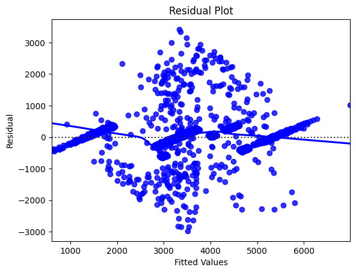

```python
# Predicted values
fitted = model2.fittedvalues
residuals = model2.resid

sns.residplot(x = fitted, y = residuals, color = 'blue', lowess = True),
plt.xlabel('Fitted Values'),
plt.ylabel('Residual'),
plt.title('Residual Plot');
```

**Obseravations:**

### **Normality of Error Terms**

The residuals should be normally distributed.

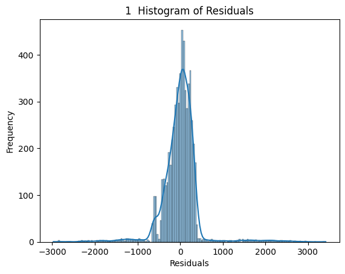

```python
# plotting histogram of residuals
sns.histplot(residuals, kde = True)
plt.title('1  Histogram of Residuals')
plt.xlabel('Residuals')
plt.ylabel('Frequency');
```

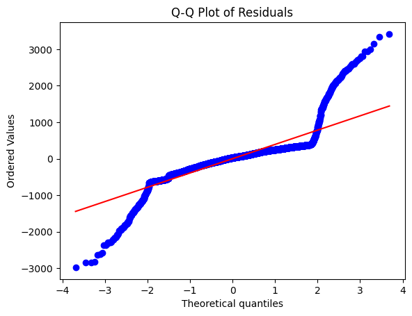

```python
# plotting q-q plot of residuals
import pylab
import scipy.stats as stats

stats.probplot(residuals, dist = 'norm', plot = pylab)
plt.title('Q-Q Plot of Residuals');
```

**Observations:**

### **Applying cross validation to improve model performance and evaluate it with different metrics**

```python
# importing the required function
from sklearn.model_selection import cross_val_score

# build the regression model and cross-validate
linearregression = LinearRegression()

cv_Score11 = cross_val_score(linearregression, x_train, y_train, cv = 10)
cv_Score12 = cross_val_score(linearregression, x_train, y_train, cv = 10,
                             scoring = 'neg_mean_squared_error')

print('R-Squared: %0.3f (+/- %0.3f)' % (cv_Score11.mean(), cv_Score11.std()*2))
print('MSE: %0.3f (+/- %0.3f)' % (-1*cv_Score12.mean(), cv_Score12.std()*2))
```

```
R-Squared: 0.823 (+/- 0.045)
MSE: 200712.689 (+/- 64085.512)
```

**Observations:**

## **Actionable Insights and Business Recommendations**

- We have built a model that is capable of predicting future sales for SuperKart in the next quarter. The model's metrics show that is epxlains ~80% of the variation in the data.
- **OUT004** - is currently the chain's best performing store, bringing in more than 2x the revenue of the next closest store. The store is currently a medium sized outlet, so ownership could consider expanding the size of the outlet given its outstanding performance. They can also use this store as a case-study and look to open similar stores in similar cities/neighborhoods (demographicaly).
- **OUT002** - is a small sized food mart in a Tier 3 city that is also performing well for its size. SuperKart can likewise look into expanding the size of the store and/or opening other similarly size stores in similar neighborhoods.
- **OUT001** - is a Supermarket Type 1 in a tier 2 city. It is the oldest of the four stores examined in this dataset, and a the lowest revenue generator for a store of it's size. It is possible that the age of the store is disuading customers from shopping there/from purchasing goods. The chain may want to consider rennovating the outlet to more modern standards. Additional marketing opportunitites may exist to incentivize customers to shop there.
- **OUT003** - is a Departmental Type store in a Tier 1 city. It is the most prevmium outlet of the chain, with the highest priced goods. SuperKart should ensure that their target demographic is in reach and that they are carrying goods that cater to these customers, given that it is a higher end outlet.

**Additional information that would help modelling sales forecasts**